# Descriptive_stats_floatyplants

Gabriel Herrick

March 3, 2015

# Getting Started

## What is this?

I want you to start your analysis of the floating plant data by focusing on descriptive statistics. Descriptive statistics are things like measures of central tendency (e.g. mean, median, mode) and dispersion (e.g. standard deviation). Personally, I think that it is far too common for biologists to place far too much emphasis put on hypothesis testing using p-values. Part of this comes from a shaky foundation in descriptive statistics. So, before we do any p-value based hypothesis testing (if we do any at all), we are going to thoroughly describe our data.

## Getting set up

R is a free, open-source program used by anybody who is a badass statistics ninja. That’s pretty much reason(s) enough to use it.

### Step one

[Downlad R](http://cran.rstudio.com)

### Step two

[Download RStudio](http://www.rstudio.com/products/rstudio/download/)

### Step three

[Spend the rest of your life playing in R](http://www.rstudio.com/resources/training/online-learning/#R)

### Step four

Make a new folder in your computer and put in the file “Full_lemna_data.csv”. Make a new Rscript in Rstudio by using the newfile tab. Save the script in your new folder with the csv file. Go to the “Session” tab and set working directory to source file location. R likes to keep track of a “working directory” where it can load and write files. You are telling R to use the your directory (folder) with the right files in it.

## First steps in R

The first thing we need to do is load our csv file into R. You should attempt to type all of the code I provide below into R yourself. Don’t just copy and paste. You don’t have to copy all the comments starting with the “#” symbol.

```r
library(dplyr)
setwd("~/Documents/Floating_Plants")
# Enter in the data
full.data <- read.csv( "Full_lemna_data.csv", header = T)
lemna <- tbl_df(full.data)
lemna # should print nicely
```

```
## Source: local data frame [72 x 5]
##
##    Week Treatment Pop.size Mass..g. X..cover
## 1     0         C       10      0.0       NA
## 2     0         L       10      0.0       NA
## 3     0         H       10      0.0       NA
## 4     1         C       13      0.0       NA
## 5     1         L       14      0.0       NA
## 6     1         H       32      0.0       NA
## 7     2         C       24      0.0       NA
## 8     2         L       27      0.0       NA
## 9     2         H       54      0.1       NA
## 10    3         C       25      0.0       NA
## ..  ...       ...      ...      ...      ...
```

```r
# Select chosen data
# Use dplyr tool "select" and rename columns in one go.
lemna <- select(lemna, week = Week, treatment = Treatment, pop.size = Pop.size)
lemna
```

```
## Source: local data frame [72 x 3]
##
##    week treatment pop.size
## 1     0         C       10
## 2     0         L       10
## 3     0         H       10
## 4     1         C       13
## 5     1         L       14
## 6     1         H       32
## 7     2         C       24
## 8     2         L       27
## 9     2         H       54
## 10    3         C       25
## ..  ...       ...      ...
```

What did we just do?

- “read.csv” reads in a comma separated values file. Excel saves files in this format so that they can be easily read by other applications. The header argument says the file has a row of names at the top.

What does this stuff look like? You should see in your environment window the data frame “lemna”. Click on that to see this data frame.

This might look a little unusual at first, but this is actually really tidy data to start out with

## What do we want to do?

We want to ask our data: What are typical values for each treatment? Do the values for treatments differ?

In order to answer the first question, we can calculate the mean number of plants at the end of our experiment. They all started out with 10 plants, so the number at the end should give us a good indication of growth.

```r
# Use grouping functions to let R know that treatment and week are grouping variables
by.treatment <- group_by(lemna, treatment, week)
by.treatment
```

```
## Source: local data frame [72 x 3]
## Groups: treatment, week
##
##    week treatment pop.size
## 1     0         C       10
## 2     0         L       10
## 3     0         H       10
## 4     1         C       13
## 5     1         L       14
## 6     1         H       32
## 7     2         C       24
## 8     2         L       27
## 9     2         H       54
## 10    3         C       25
## ..  ...       ...      ...
```

```r
pop <- summarize(by.treatment, number = mean(pop.size))
pop # This table shows us means for each treatment arranged by week.
```

```
## Source: local data frame [18 x 3]
## Groups: treatment
##
##    treatment week number
## 1          C    0  10.00
## 2          C    1  12.25
## 3          C    2  20.75
## 4          C    3  25.75
## 5          C    4  21.00
## 6          C    5  20.25
## 7          H    0  10.00
## 8          H    1  22.75
## 9          H    2  50.50
## 10         H    3 155.25
## 11         H    4 222.50
## 12         H    5 280.00
## 13         L    0  10.00
## 14         L    1  17.50
## 15         L    2  40.50
## 16         L    3  84.75
## 17         L    4 129.00
## 18         L    5 177.25
```

```r
pop.range <- summarize(by.treatment, min = min(pop.size), max = max(pop.size))
pop.range # This shows us the range
```

```
## Source: local data frame [18 x 4]
## Groups: treatment
##
##    treatment week min max
## 1          C    0  10  10
## 2          C    1  11  13
## 3          C    2  17  24
## 4          C    3  23  28
## 5          C    4  12  25
## 6          C    5   5  33
## 7          H    0  10  10
## 8          H    1  18  32
## 9          H    2  34  59
## 10         H    3 102 186
## 11         H    4 150 260
## 12         H    5 280 280
## 13         L    0  10  10
## 14         L    1  14  20
## 15         L    2  27  46
## 16         L    3  54 109
## 17         L    4  83 159
## 18         L    5 144 207
```

### Let’s talk about this data

We have a list of average values for each container in each treatment in each week. Of course, we want to summarize this data a little bit better, but how?

### The five-number summary

The five-number summary of the data consists of the minimum data point, the first quartile, the median, the third quartile, and the maximum data point. Thus these five numbers display the full range of variation (from minimum to maximum), the common range of variation (from first to third quartile), and a typical value (the median). -[source](http://www.physics.csbsju.edu/stats/descriptive2.html)

```r
# The five-number summary

summary.table <- with(by.treatment, (tapply(pop.size, list("nutrient"=treatment,
                                                          "week"=week), summary)))
summary.pretty <- as.data.frame(summary.table)

names(summary.pretty) <- c("week 0", "week 1", "week 2", "week 3", "week 4",
                         "week 5")
row.names(summary.pretty) <- c( "Control", "High", "Low")
# Let's look at a little of the data,
# Here is the summary data for the last week
summary.pretty[, 6]
```

```
## $C
##    Min. 1st Qu.  Median    Mean 3rd Qu.    Max.
##    5.00   17.00   21.50   20.25   24.75   33.00
##
## $H
##    Min. 1st Qu.  Median    Mean 3rd Qu.    Max.
##     280     280     280     280     280     280
##
## $L
##    Min. 1st Qu.  Median    Mean 3rd Qu.    Max.
##   144.0   165.0   179.0   177.2   191.2   207.0
```

Okay, but this is in table form, and tables are hard to read for humans. What kind of graphical representation of this data might be appropriate? [Box plots](http://en.wikipedia.org/wiki/Box_plot) are explicitly designed to view summary data. Cool.

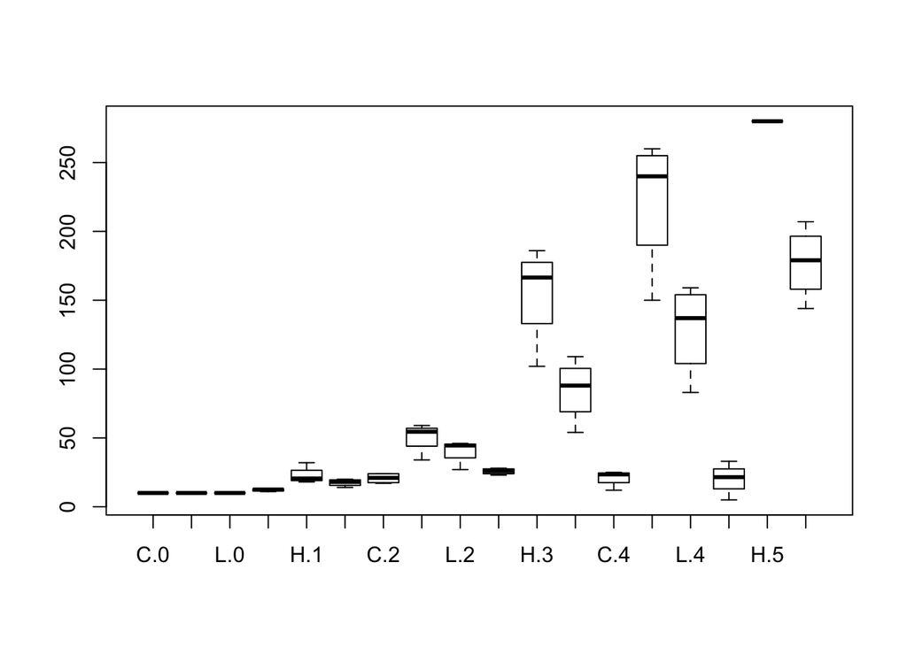

```r
boxplot(pop.size ~ treatment*week, data=lemna)
```

```r
# This is a lot to look at in one plot. Maybe it makes more sense to look
# at an individual week or two

# Week 2
week2.data <- filter( lemna, week==2)
week2.data
```

```
## Source: local data frame [12 x 3]
##
##    week treatment pop.size
## 1     2         C       24
## 2     2         L       27
## 3     2         H       54
## 4     2         C       24
## 5     2         L       45
## 6     2         H       34
## 7     2         C       17
## 8     2         L       44
## 9     2         H       55
## 10    2         C       18
## 11    2         L       46
## 12    2         H       59
```

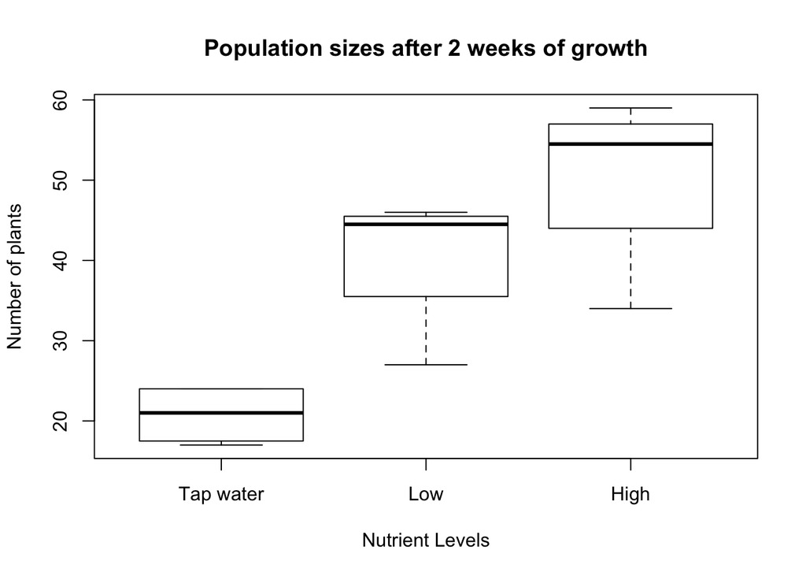

```r
plotfactor <- as.factor(rep(c(1, 2, 3), 4))
boxplot(pop.size ~ plotfactor, data=week2.data,
        names = c("Tap water", "Low", "High"), ylab = "Number of plants",
        xlab = "Nutrient Levels",
        main = "Population sizes after 2 weeks of growth")
```

Now we are getting somewhere! What does this tell us? What do you see here? Look at the overlap in the boxes and whiskers between high and low treatments. This tells us that maybe these two groups of plants aren’t so different. Look at how the median value for the low treatment is way up at the top of the box. This means that the data is skewed, i.e. non-normal -the low values are much more spread out than larger values. Try doing a Google search for “interpreting box plots” for more information.